# Visual Story about Public Transport

## Description of How my Data was collected

My visual data story is based on a dataset collected through a short online survey focused on public transport experiences in Auckland. It has 44 observations in total. The survey was designed to capture how reliable public transport feels to everyday users, particularly in terms of punctuality, waiting time, and crowding. Responses were gathered by sharing a Google Form with participants around university campuses and through social media platforms. In addition to external responses, I also contributed my own journey data. Each participant recorded details from a recent trip, ensuring the information reflected real and relatively fresh experiences. Each observation in the dataset represents a single journey and includes both numerical and categorical variables. Numerical data includes waiting time before boarding and minutes late, while categorical responses capture transport type, time of day, day type (weekday or weekend), and perceived crowding levels.

## Plot 1 - Bar graph showing which transport type is mostly used by Passengers.

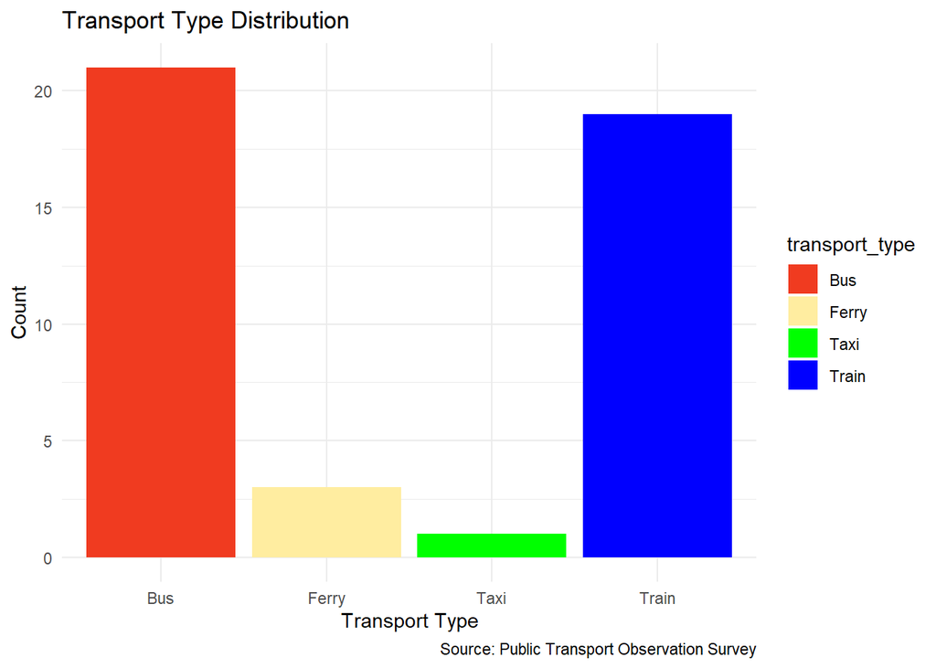